# Métodos de Agrupamentos Hierárquicos

Carolina Medeiros, Letícia Felix, Marcson de Azevedo e Rayssa da Paz

13/04/2021

### Introdução

Análise de agrupamentos é uma técnica exploratória importante que tem como objetivo procurar pela estrutura “natural” que os dados apresentam.

Segundo Everitt (2001), **métodos hierárquicos** são técnicas triviais em que os dados são divididos sequencialmente, a fim de se produzir uma representação hierárquica dos agrupamentos, ou seja, uma visualização ordenada destes. Tal ordenação serve para facilitar a observação da estruturação dos agrupamentos em cada estágio, bem como o grau de semelhança entre os grupos formados.

A segmentação de dados por seus atributos é uma ferramenta útil em diversas áreas e contextos, como: identificação de similaridades entre consumidores; detecção de anomalias (outliers) em reconhecimento de fraudes; sequenciamento de dna; rastreamento de vírus; etc.

O Método Hieráquico, não necessita de um número de agrupamentos definido préviamente. Os agrupamentos são definidos através da análise gráfica de um **dendrograma** elaborado a partir das distâncias entre os grupos. Um dendrograma é um tipo de gráfico que exibe a hierarquia e a relação dos agrupamentos na forma de uma estrutura de árvore.

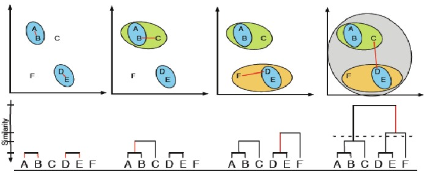

Representação gráfica do dendograma

Em um contexto mais amplo da organização de dados, os metódos hierárquicos são formas de organizar os dados sem uma variável dependente, de forma que não existe resultado “certo” ou “errado” na construção dos grupos, também conhecidos como clusters. Diferentemente de metódos de classificação, que buscam encontrar uma resposta de certo ou errado para uma variável de interesse.

### Métodos Hierárquicos

Métodos Hierárquicos são caracterizados pelas **matrizes de similaridades entre agrupamentos**. Essas matrizes são denominadas assim por conterem as métricas de distância entre os agrupamentos em cada estágio do algoritmo, representando assim os valores de proximidade entre os agrupamentos.

Estes métodos são subdivididos em **Métodos Aglomerativos** e **Métodos Divisivos**.

Os **Métodos Aglomerativos** são os mais comuns entre os métodos hierárquicos. Este método se inicia com cada observação sendo seu próprio grupo, que depois é unido ao grupo mais similar. Os grupos são sucessivamente unidos até que se tenha apenas um cluster.

Esse procedimento é feito da seguinte maneira:

Primeiro, é criada a matriz de similaridades utilizando-se do cálculo de distâncias escolhido. O próximo passo consiste em encontrar o menor valor na matriz, ou seja, a menor distância entre grupos, que identifica os dois agrupamentos mais similares entre si. Feito isso, esses dois grupos identificados são agrupados por uma **ligação** e formam assim um novo agrupamento. Logo em seguida, a matriz de similaridades é atualizada, contendo agora um agrupamento a menos. Este procedimento é repetido até restar apenas um único agrupamento.

Uma das desvantagens deste método está no fato de que os agrupamentos não são corrigidos. Uma vez que são formados, permanecem com a mesma ligação até o fim do método.

A ligação é uma característica dos métodos aglomerativos, são formas de agrupar os objetos semelhantes. Os tipos de ligação mais comuns são: Ligações Simples (vizinho mais próximo), Ligações Completas (vizinho mais distante), Método das Médias das Distâncias, Método do Centróide e Método de Ward. Na aplicação avaliaremos os resultados com diferentes formas de ligação.

Os métodos divisivos são os menos comuns entre os métodos hierárquicos, devido a sua ineficiência e a alta capacidade computacional que exigem. (Costa 1999)

Esse método começa com um único grupo formado por todas as observações e gradualmente vai dividindo os agrupamentos em clusters menores até a etapa final, onde cada observação é um agrupamento. A ideia é achar a partição que minimiza a matriz de similaridades.

O procedimento geral pode ser descrito em poucos passo:

$1$ - Início: Um único agrupamento contendo todos os padrões.

$2$ - Calcula-se a matriz de similaridades entre todos os possíveis pares de agrupamentos.

$3$ - Forma-se um novo agrupamento pela divisão dos pares de agrupamentos com menor grau de similaridade.

$4$ - Os passos $2$ e $3$ são executados até que se tenha uma agrupamento por padrão.

Apesar da dificuldade computacional, WinIDAMS (2005) diz que os métodos divisivos possuem a vantagem de considerar muitas divisões no primeiro passo, diminuindo a probabilidade de uma decisão errada, sendo assim, mais seguros que os métodos aglomerativos.

### Passo a passo

A aplicação do método busca calcular as distâncias entre os fatores para que se possa classificar os objetos em uma hierarquia de similaridades.

Existem muitas formas de medir estas distâncias, como: a Métrica de Minkowski; a Distância de Mahalanobis; a Distância city-block (Manhattan); a Distância Euclidiana e o Quadrado dela. Neste trabalho foi escolhida a distância Euclidiana, que pode ser calculada da seguinte forma:

$$d_{i,j} = \sqrt{(i - j)^2}$$

O cálculo da distância $d_{i,j}$ será o elemento da linha $i$ e da coluna $j$ da matriz de similaridades de agrupamentos. A matriz $D$ será composta pelas distâncias de cada elemento. No início do método de agrupamento hierárquico teremos N grupos, logo a matriz $D$ será quadrada de tamanho NxN e a diagonal principal igual a zero pois serão os elementos $d_{i,i}$.

Após a construção da matriz, será aplicada a forma de agrupamento que a reduzirá através de um método aglomerativo, ou a dividirá por um método divisivo. Seguindo com o método aglomerativo, temos que na próxima etapa será aplicada uma forma de ligação que irá definir N-1 grupos e, então, atualizar a matriz de similaridades.

Com a hierarquia montada e definidos os agrupamentos, no caso aglomerativo, num grupo único final, será utilizada a ligação simples para construir um dendrograma e finalmente definir os agrupamentos.

##### **Coeficiente Aglomerativo**

O coeficiente aglomerativo é uma medida de qualidade de um agrupamento aglomerativo. O cálculo desta medida leva em consideração, para cada observação, a razão entre a dissimilaridade em relação ao primeiro agrupamento onde foi inserida e a dissimilaridade na etapa final do algoritmo, denotada por di na fórmula abaixo.

O coeficiente é definido como:

$$CA = \frac{1}{n}\sum_{i=1}^{N}{1-d_i}$$

Os valores do coeficiente variam entre 0 e 1. Valores próximos de 1 indicam que estruturas bem definidas foram identificadas, enquanto valores baixos indicam estruturas ruins ou agrupamentos mal definidos.

Para métodos divisivos, existe o coeficiente divisivo. Este não será abordado neste material, já que o método útilizado será o aglomerativo.

### Aplicação no R

##### **Primeira aplicação**

Buscamos aplicar abordagens diretas, para o entendimento do método. Vamos explorar um trabalho mais teórico e uma segunda aplicação para valores reais.

Dado um banco de dados:

```
##   empresa gastos lucros
## 1      E1     50     70
## 2      E2     35     45
## 3      E3     32     45
## 4      E4     52     60
## 5      E5     30     40
## 6      E6     45     48
```

Remova as colunas para ficar só com dos dados quantitativos: Também é importante garantir que observações faltantes sejam removidas ou estimadas.

```
##   gastos lucros
## 1     50     70
## 2     35     45
## 3     32     45
## 4     52     60
## 5     30     40
## 6     45     48
```

Nomear as linhas de acordo com a primeira coluna:

```
##    gastos lucros
## E1     50     70
## E2     35     45
## E3     32     45
## E4     52     60
## E5     30     40
## E6     45     48
```

```
##    gastos lucros
## E1     50     70
## E2     35     45
## E3     32     45
## E4     52     60
## E5     30     40
## E6     45     48
```

Calcular a matriz de distâncias entre os casos E1, E2,…

```
##      E1   E2   E3   E4   E5
## E2  850
## E3  949    9
## E4  104  514  625
## E5 1300   50   29  884
## E6  509  109  178  193  289
```

Fazer o cluster hierarquico, segundo o método de Ligação Simples:

```r
grupos_simples <- hclust(d2, method = "single") #Ligação Simples
grupos_simples
```

```
##
## Call:
## hclust(d = d2, method = "single")
##
## Cluster method   : single
## Distance         : euclidean
## Number of objects: 6
```

Há outros métodos conforme descritos abaixo:

```r
grupos_completos <- hclust(d2, method = "complete") #Ligação Completa
grupos_medios <- hclust(d2, method = "average") #Ligação Média
grupos_ward <- hclust(d2, method = "ward") #Método de Ward
```

Fazer o dendograma:

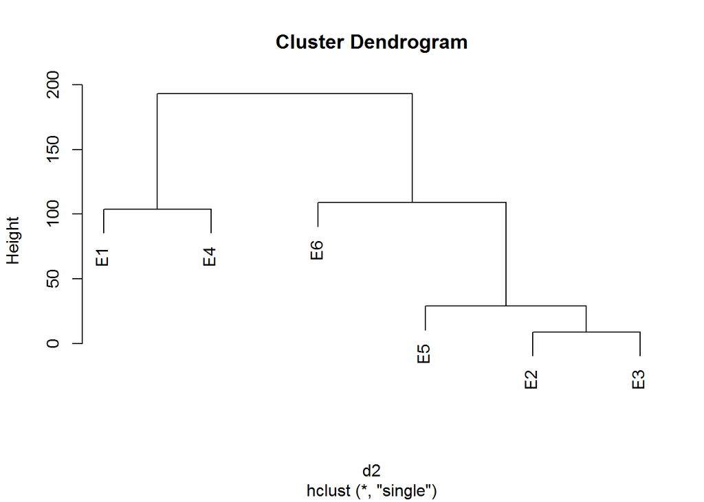

```r
clust_s <- grupos_simples
plot(clust_s)
```

Selecionar o número de grupos adequado para ser observado:

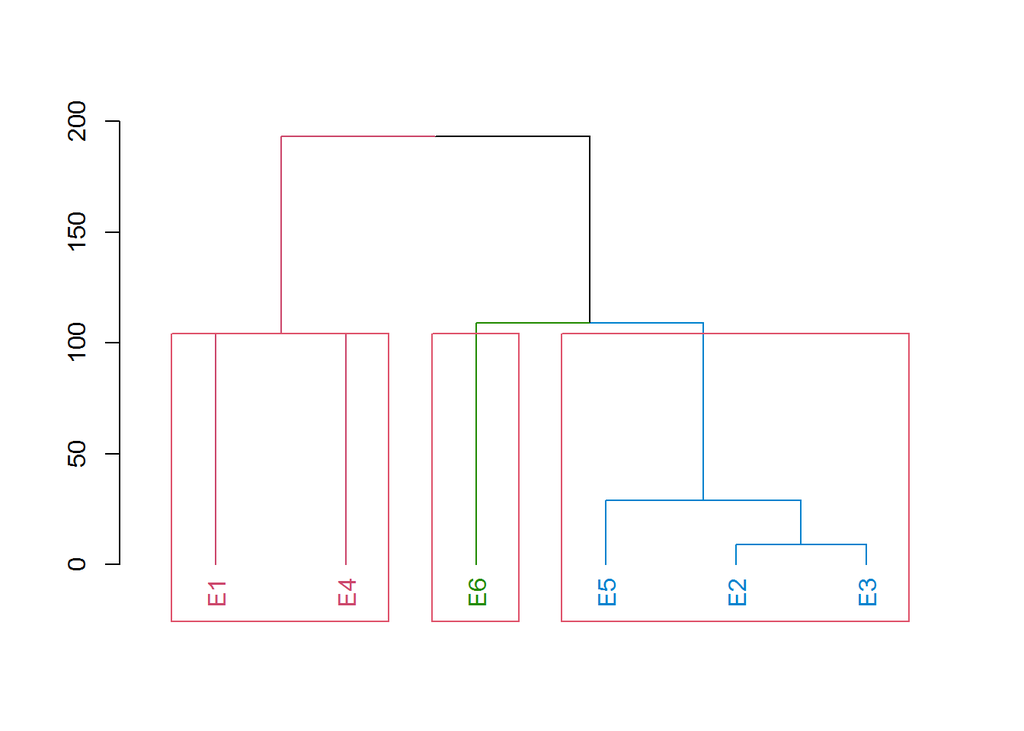

```r
library(dplyr)
library(dendextend)
grupos <- cutree(clust_s,k=3)
dend <- grupos_simples %>% as.dendrogram()

dend %>% color_branches(k=3) %>% color_labels(k=3) %>% plot
dend %>% rect.dendrogram(k=3)
```

Verificando a análise completa:

```r
clust_s[]
```

```
## $merge
##      [,1] [,2]
## [1,]   -2   -3
## [2,]   -5    1
## [3,]   -1   -4
## [4,]   -6    2
## [5,]    3    4
##
## $height
## [1]   9  29 104 109 193
##
## $order
## [1] 1 4 6 5 2 3
##
## $labels
## [1] "E1" "E2" "E3" "E4" "E5" "E6"
##
## $method
## [1] "single"
##
## $call
## hclust(d = d2, method = "single")
##
## $dist.method
## [1] "euclidean"
```

Observando a lista dos membros de cada agrupamento:

```r
grupos
```

```
## E1 E2 E3 E4 E5 E6
##  1  2  2  1  2  3
```

##### **Segunda aplicação**

Agora, vamos aplicar um método aglomerativo com dados reais

A base de dados foi coletada do Spotify e é composta por observações das faixas do álbum “4” da Beyoncé. Nesta base há informações sobre a “dançabilidade” das músicas (que vai de 0 a 1) e sobre sua popularidade no Spotify (que vai de 0 a 100).

```r
library(tidyverse)
library(cluster)
library(factoextra)
library(dendextend)


dados = read.csv('dados_album_4_beyonce.csv', encoding = 'UTF-8')
dados = dplyr::select(dados, Nome, Popularidade, Dancabilidade)
row.names(dados)=dados[,1]
dados = na.omit(dados)
dados
```

```
##                                              Nome Popularidade Dancabilidade
## Love On Top                           Love On Top           76         0.652
## Party (feat. Andre 3000) Party (feat. Andre 3000)           63         0.648
## Schoolin' Life                     Schoolin' Life           54         0.799
## Countdown                               Countdown           66         0.665
## I Miss You                             I Miss You           54         0.718
## Dance for You                       Dance for You           65         0.616
## I Care                                     I Care           55         0.371
## Rather Die Young                 Rather Die Young           48         0.628
## 1+1                                           1+1           58         0.303
## End of Time                           End of Time           64         0.711
## Run the World (Girls)       Run the World (Girls)           75         0.733
## Best Thing I Never Had     Best Thing I Never Had           74         0.545
## Start Over                             Start Over           50         0.474
## I Was Here                             I Was Here           60         0.510
```

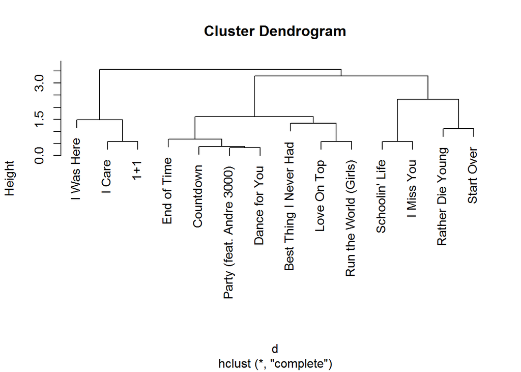

```r
dados = scale(dados[,2:3])
dados = as.matrix(dados)
d = dist(dados, method = 'euclidean')

hc1 = hclust(d, method='complete')

plot(hc1)
```

Vamos aplicar o método Agnes que permite calcular o coeficiente aglomerativo.

```r
hc2 = agnes(dados, method='complete')
hc2$ac
```

```
## [1] 0.7962202
```

```r
m <- c( "average", "single", "complete", "ward")
names(m) <- c( "average", "single", "complete", "ward")

# funcao para computar o coeficiente
ac <- function(x) {
  agnes(dados, method = x)$ac
}

map_dbl(m, ac)
```

```
##   average    single  complete      ward
## 0.7269913 0.4594769 0.7962202 0.8597250
```

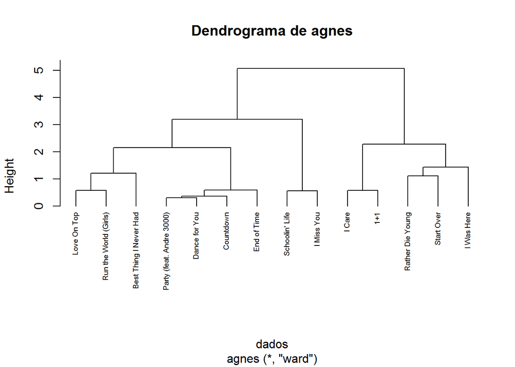

```r
hc3 <- agnes(dados, method = "ward")
pltree(hc3, cex = 0.6, hang = -1, main = "Dendrograma de agnes")
```

```r
sub_grp = cutree(hc1, k=3)
```

Temos então como resultado o número de membros em cada grupo.

```r
table(sub_grp)
```

```
## sub_grp
## 1 2 3
## 7 4 3
```

```r
sub_grp
```

```
##              Love On Top Party (feat. Andre 3000)           Schoolin' Life
##                        1                        1                        2
##                Countdown               I Miss You            Dance for You
##                        1                        2                        1
##                   I Care         Rather Die Young                      1+1
##                        3                        2                        3
##              End of Time    Run the World (Girls)   Best Thing I Never Had
##                        1                        1                        1
##               Start Over               I Was Here
##                        2                        3
```

#### Bibliografia

- Costa, 1999
- Everitt, 2001
- WinIDAMS, 2005